# CAE

**Convolutional Autoencoder**

Initialized by Sung Wook Kim  
Modified By Prof. Seungchul Lee  
http://iai.postech.ac.kr/  
Industrial AI Lab at POSTECH

Table of Contents

Source

- http://www.cvc.uab.es/people/joans/slides_tensorflow/tensorflow_html/layers.html
- https://towardsdatascience.com/types-of-convolutions-in-deep-learning-717013397f4d
- https://github.com/vdumoulin/conv_arithmetic

# 1. Convolution

## 1.1. 2D Convolution

```
tf.nn.conv2d(input, filter, strides, padding)

    input = [None, input_h, input_w, input_ch]
    filter = [k_h, k_w, input_ch, output_ch]
    padding = 'VALID'
    strides = [1, s_h, s_w, 1]
```

- Kernel Size
  - the field of view of the convolution.
- Stride
  - the step size of the kernel when traversing the image.
- Padding
  - how the border of a sample is handled.
  - A padded convolution will keep the spatial output dimensions equal to the input, whereas unpadded convolutions will crop away some of the borders if the kernel is larger than 1.
- Input & Output Channels
  - A convolutional layer takes a certain number of input channels (I) and calculates a specific number of output channels (O).
  - The needed parameters for such a layer can be calculated by $I \times O \times K$, where $K$ equals the number of values in the kernel.

```
input = [None,4,4,1]
kernel = [3,3,1,1]
padding = 'VALID'
strides = [1,1,1,1]
```

[figure not shown]

```
input = [None,5,5,1]
kernel = [3,3,1,1]
padding = 'SAME'
strides = [1,1,1,1]
```

[figure not shown]

```
input = [None,5,5,1]
kernel = [3,3,1,1]
padding = 'SAME'
strides = [1,2,2,1]
```

[figure not shown]

## 1.2. Dilated Convolutions

(a.k.a. atrous convolutions)

```
tf.nn.atrous_conv2d(value, filters, rate, padding)
```

Dilated convolutions introduce another parameter to convolutional layers called the dilation rate. This defines a spacing between the values in a kernel. A 3x3 kernel with a dilation rate of 2 will have the same field of view as a 5x5 kernel, while only using 9 parameters. Imagine taking a 5x5 kernel and deleting every second column and row.

This delivers a wider field of view at the same computational cost. Dilated convolutions are particularly popular in the field of real-time segmentation. Use them if you need a wide field of view and cannot afford multiple convolutions or larger kernels.

[figure not shown]

2D convolution using a 3 kernel with a dilation rate of 2 and no padding

# 2. (Inverse) Convolution

## 2.1. Transposed Convolutions

(a.k.a. deconvolutions or fractionally strided convolutions)

```
tf.nn.conv2d_transpose(value, filter, output_shape, strides, padding='SAME')
```

- Some sources use the name deconvolution, which is inappropriate because it’s not a deconvolution. To make things worse deconvolutions do exists, but they’re not common in the field of deep learning.
- An actual deconvolution reverts the process of a convolution.
- Imagine inputting an image into a single convolutional layer. Now take the output, throw it into a black box and out comes your original image again. This black box does a deconvolution. It is the mathematical inverse of what a convolutional layer does.
- A transposed convolution is somewhat similar because it produces the same spatial resolution a hypothetical deconvolutional layer would. However, the actual mathematical operation that’s being performed on the values is different.
- A transposed convolutional layer carries out a regular convolution but reverts its spatial transformation.

An image of 5x5 is fed into a convolutional layer. The stride is set to 2, the padding is deactivated and the kernel is 3x3. This results in a 2x2 image.

[figure not shown]

If we wanted to reverse this process, we’d need the inverse mathematical operation so that 9 values are generated from each pixel we input. Afterward, we traverse the output image with a stride of 2. This would be a deconvolution.

A transposed convolution does not do that. The only thing in common is it guarantees that the output will be a 5x5 image as well, while still performing a normal convolution operation. To achieve this, we need to perform some fancy padding on the input.

[figure not shown]

Transposed 2D convolution with no padding, stride of 2 and kernel of 3

It merely reconstructs the spatial resolution from before and performs a convolution. This may not be the mathematical inverse, but for Encoder-Decoder architectures, it’s still very helpful. This way we can combine the upscaling of an image with a convolution, instead of doing two separate processes.

- Another example of transposed convolution

[figure not shown]

Transposed 2D convolution with no padding, no stride and kernel of 3

# 3. Examples

SegNet

[figure not shown]

DeconvNet

[figure not shown]

# 4. CAE with MNIST

```python
import numpy as np
import matplotlib.pyplot as plt
import tensorflow as tf
```

```python
from tensorflow.examples.tutorials.mnist import input_data
mnist = input_data.read_data_sets("MNIST_data/", one_hot=True)
```

```
Extracting MNIST_data/train-images-idx3-ubyte.gz
Extracting MNIST_data/train-labels-idx1-ubyte.gz
Extracting MNIST_data/t10k-images-idx3-ubyte.gz
Extracting MNIST_data/t10k-labels-idx1-ubyte.gz
```

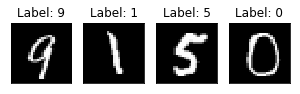

```python
train_x, train_y = mnist.train.next_batch(10)
img1 = train_x[3,:].reshape(28,28)
img2 = train_x[4,:].reshape(28,28)
img3 = train_x[5,:].reshape(28,28)
img4 = train_x[6,:].reshape(28,28)

fig = plt.figure(figsize=(5, 3))

ax1 = fig.add_subplot(2, 4, 1)
ax1.imshow(img1, 'gray')
ax1.set_title("Label: {}".format(np.argmax(train_y[3,:])))
ax1.set_xticks([])
ax1.set_yticks([])

ax2 = fig.add_subplot(2, 4, 2)
ax2.imshow(img2, 'gray')
ax2.set_title("Label: {}".format(np.argmax(train_y[4,:])))
ax2.set_xticks([])
ax2.set_yticks([])

ax3 = fig.add_subplot(2, 4, 3)
ax3.imshow(img3, 'gray')
ax3.set_title("Label: {}".format(np.argmax(train_y[5,:])))
ax3.set_xticks([])
ax3.set_yticks([])

ax4 = fig.add_subplot(2, 4, 4)
ax4.imshow(img4, 'gray')
ax4.set_title("Label: {}".format(np.argmax(train_y[6,:])))
ax4.set_xticks([])
ax4.set_yticks([])

plt.show()
```

```python
def batch_maker(batch_size, img, label):
    img_len = len(img)
    random_idx = np.random.randint(img_len, size = batch_size)
    return img[random_idx], label[random_idx]
```

```python
train_idx = ((np.argmax(mnist.train.labels, 1) == np.argmax(train_y[3,:])) | \
             (np.argmax(mnist.train.labels, 1) == np.argmax(train_y[4,:])) | \
             (np.argmax(mnist.train.labels, 1) == np.argmax(train_y[5,:])) | \
             (np.argmax(mnist.train.labels, 1) == np.argmax(train_y[6,:])))
test_idx = ((np.argmax(mnist.test.labels, 1) == np.argmax(train_y[3,:])) | \
            (np.argmax(mnist.test.labels, 1) == np.argmax(train_y[4,:])) | \
            (np.argmax(mnist.test.labels, 1) == np.argmax(train_y[5,:])) | \
            (np.argmax(mnist.test.labels, 1) == np.argmax(train_y[6,:])))

train_imgs = mnist.train.images[train_idx]
train_labels = mnist.train.labels[train_idx]
test_imgs = mnist.test.images[test_idx]
test_labels = mnist.test.labels[test_idx]
n_train = train_imgs.shape[0]
n_test = test_imgs.shape[0]

print("Packages loaded")
print("The number of trainimgs : {}, shape : {}".format(n_train, train_imgs.shape))
print("The number of testimgs : {}, shape : {}".format(n_test, test_imgs.shape))
```

```
Packages loaded
The number of trainimgs : 22064, shape : (22064, 784)
The number of testimgs : 4016, shape : (4016, 784)
```

```python
input_h = 28 # Input height
input_w = 28 # Input width
input_ch = 1 # Input channel : Gray scale
# (None, 28, 28, 1)

## First convolution layer
# Filter size
k1_h = 3
k1_w = 3
# the number of channels
k1_ch = 32
# Pooling size
p1_h = 2
p1_w = 2
# (None, 14, 14, 32)

## Second convolution layer
# Filter size
k2_h = 3
k2_w = 3
# the number of channels
k2_ch = 64
# Pooling size
p2_h = 2
p2_w = 2
# (None, 7, 7, 64)

## First deconvolution layer
# Filter size
k3_h = 3
k3_w = 3
# the number of channels
k3_ch = 32
# unPooling size
p3_h = 2
p3_w = 2
# (None, 14, 14, 32)

## Second deconvolution layer
# Filter size
k4_h = 3
k4_w = 3
# the number of channels
k4_ch = 1
# unPooling size
p4_h = 2
p4_w = 2
# (None, 28, 28, 1)

## Fully connected
# Flatten the features
# -> (None, 7*7*64)
conv_result_size = int((28/(2*2)) * (28/(2*2)) * k2_ch)
latent = 10
n_output = 10
```

```python
weights = {
    'conv1' : tf.Variable(tf.random_normal([k1_h, k1_w, input_ch, k1_ch], stddev = 0.1)),
    'conv2' : tf.Variable(tf.random_normal([k2_h, k2_w, k1_ch, k2_ch], stddev = 0.1)),
    'hidden1' : tf.Variable(tf.random_normal([conv_result_size, latent], stddev = 0.1)),
    'hidden2' : tf.Variable(tf.random_normal([latent, conv_result_size], stddev = 0.1)),
    'deconv1' : tf.Variable(tf.random_normal([k3_h, k3_w, k3_ch, k2_ch], stddev = 0.1)),
    'deconv2' : tf.Variable(tf.random_normal([k4_h, k4_w, k4_ch, k3_ch], stddev = 0.1)),
    'reconst' : tf.Variable(tf.random_normal([input_h, input_w], stddev = 0.1))
}

biases = {
    'conv1' : tf.Variable(tf.random_normal([k1_ch], stddev = 0.1)),
    'conv2' : tf.Variable(tf.random_normal([k2_ch], stddev = 0.1)),
    'hidden1' : tf.Variable(tf.random_normal([latent], stddev = 0.1)),
    'hidden2' : tf.Variable(tf.random_normal([conv_result_size], stddev = 0.1)),
    'deconv1' : tf.Variable(tf.random_normal([k3_ch], stddev = 0.1)),
    'deconv2' : tf.Variable(tf.random_normal([k4_ch], stddev = 0.1)),
    'reconst' : tf.Variable(tf.random_normal([input_h, input_w], stddev = 0.1)),
}

x = tf.placeholder(tf.float32, [None, input_h, input_w, input_ch])
y = tf.placeholder(tf.float32, [None, input_h, input_w, input_ch])
```

```python
# Define encoder
def encoder(x, weights, biases):
    ## First convolution layer
    conv1 = tf.nn.conv2d(x,
                         weights['conv1'],
                         strides = [1, 1, 1, 1],
                         padding = 'SAME')
    conv1 = tf.nn.relu(tf.add(conv1, biases['conv1']))
    maxp1 = tf.nn.max_pool(conv1,
                           ksize = [1, p1_h, p1_w, 1],
                           strides = [1, p1_h, p1_w, 1],
                           padding = 'VALID')

    ## Second convolution layer
    conv2 = tf.nn.conv2d(maxp1,
                         weights['conv2'],
                         strides = [1, 1, 1, 1],
                         padding = 'SAME')
    conv2 = tf.nn.relu(tf.add(conv2, biases['conv2']))
    maxp2 = tf.nn.max_pool(conv2,
                           ksize = [1, p2_h, p2_w, 1],
                           strides = [1, p2_h, p2_w, 1],
                           padding = 'VALID')

    # shape = conv2.get_shape().as_list()
    # maxp2_re = tf.reshape(conv2, [-1, shape[1]*shape[2]*shape[3]])
    maxp2_re = tf.reshape(maxp2, [-1, conv_result_size])

    ## Fully connected
    hidden1 = tf.add(tf.matmul(maxp2_re, weights['hidden1']), biases['hidden1'])
    hidden1 = tf.nn.tanh(hidden1)
    hidden2 = tf.add(tf.matmul(hidden1, weights['hidden2']), biases['hidden2'])
    hidden2 = tf.nn.tanh(hidden2)

    return hidden2
```

```python
def decoder(hidden2, weights, biases):
    uncomp = tf.reshape(hidden2, [50, 7, 7, 64])

    ## First deconvolution layer
    deconv1 = tf.nn.conv2d_transpose(uncomp,
                                     weights['deconv1'],
                                     output_shape=(50, 14, 14, 32),
                                     strides=[1, 2, 2, 1],
                                     padding='SAME')

    ## Second deconvolution layer
    deconv2 = tf.nn.conv2d_transpose(deconv1,
                                     weights['deconv2'],
                                     output_shape=(50, 28, 28, 1),
                                     strides=[1, 2, 2, 1],
                                     padding='SAME')

    return deconv2
```

```python
LR = 0.0001

latent = encoder(x, weights, biases)
reconst = decoder(latent, weights, biases)
loss = tf.square(tf.subtract(y, reconst))
loss = tf.reduce_mean(loss)

optm = tf.train.AdamOptimizer(LR).minimize(loss)

init = tf.global_variables_initializer()
```

```python
n_batch = 50
n_iter = 10000
n_prt = 250
```

```python
# Run initialize
# config = tf.ConfigProto(allow_soft_placement=True)  # GPU Allocating policy
# sess = tf.Session(config=config)
sess = tf.Session()
sess.run(init)
```

```python
# Training cycle
for epoch in range(n_iter):
    train_x, _ = batch_maker(n_batch, train_imgs, train_labels)
    train_y = train_x.copy()
    sess.run(optm, feed_dict={x : np.reshape(train_x, [-1, input_h, input_w, 1]),
                              y : np.reshape(train_y, [-1, input_h, input_w, 1])})

    if epoch % n_prt == 0:
        c = sess.run(loss, feed_dict={x : np.reshape(train_x, [-1, input_h, input_w, 1]),
                                      y : np.reshape(train_y, [-1, input_h, input_w, 1])})
        print ("Iter : {}".format(epoch))
        print ("Cost : {}".format(c))
```

```
Iter : 0
Cost : 0.15768828988075256
Iter : 250
Cost : 0.05468957498669624
Iter : 500
Cost : 0.040796659886837006
Iter : 750
Cost : 0.039294417947530746
Iter : 1000
Cost : 0.035857170820236206
Iter : 1250
Cost : 0.03274121508002281
Iter : 1500
Cost : 0.031390123069286346
Iter : 1750
Cost : 0.0337907075881958
Iter : 2000
Cost : 0.030458854511380196
Iter : 2250
Cost : 0.029076870530843735
Iter : 2500
Cost : 0.02893512323498726
Iter : 2750
Cost : 0.028608541935682297
Iter : 3000
Cost : 0.028075050562620163
Iter : 3250
Cost : 0.029998542740941048
Iter : 3500
Cost : 0.02966373972594738
Iter : 3750
Cost : 0.032465964555740356
Iter : 4000
Cost : 0.025866983458399773
Iter : 4250
Cost : 0.029203083366155624
Iter : 4500
Cost : 0.02799251675605774
Iter : 4750
Cost : 0.02950679324567318
```

[output cut: 25 more lines]

```
Cost : 0.02655910514295101
Iter : 8250
Cost : 0.028806224465370178
Iter : 8500
Cost : 0.02807663567364216
Iter : 8750
Cost : 0.026322107762098312
Iter : 9000
Cost : 0.02946455404162407
Iter : 9250
Cost : 0.0289441104978323
Iter : 9500
Cost : 0.028238262981176376
Iter : 9750
Cost : 0.028501536697149277
```

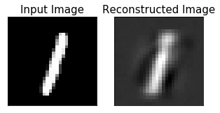

```python
test_x, _ = batch_maker(n_batch, test_imgs, test_labels)
test_y = test_x.copy()
x_reconst = sess.run(reconst, feed_dict={x : np.reshape(test_x, [-1, input_h, input_w, 1])})

fig = plt.figure(figsize=(5, 3))
ax1 = fig.add_subplot(1, 2, 1)
ax1.imshow(test_x[0].reshape(28, 28), 'gray')
ax1.set_title('Input Image', fontsize=15)
ax1.set_xticks([])
ax1.set_yticks([])

ax2 = fig.add_subplot(1, 2, 2)
ax2.imshow(x_reconst[0].reshape(28, 28), 'gray')
ax2.set_title('Reconstructed Image', fontsize=15)
ax2.set_xticks([])
ax2.set_yticks([])
plt.show()
```

```python
%%javascript
$.getScript('https://kmahelona.github.io/ipython_notebook_goodies/ipython_notebook_toc.js')
```